# ASRS UAS Reports: Descriptive Analysis

Author

Michael J. Hickey

Published

December 27, 2025

# Descriptive Findings: ASRS UAS Encounter Reports

*Draft generated: 2025-12-27*

## Data overview and completeness

This analysis examines 50 UAS encounter reports from the NASA Aviation Safety Reporting System (ASRS), spanning 2024-11-01 to 2025-03-01. The dataset contains 125 coded fields per report.

Key observations about data completeness:

- The dataset represents a curated sample of UAS encounters, not a random sample of all aviation safety reports.
- Core identification fields (report ID, date) are complete for all 50 reports.
- Operational context variables (time of day, flight phase, airspace) are available for the majority of reports, though availability varies by field.
- Event coding fields (anomaly tags, contributing factors) are complete, reflecting ASRS analyst review.
- Miss distance information is available for a subset of reports where proximity data was reported and parseable.
- ‘Unknown’ values in summaries indicate missing or not reported data, not a distinct category.

## Operational context of encounters

**Time of day**: The most common reporting period was 1201-1800, accounting for 21 of 46 reports with time data available (45.7%). This aligns with typical daytime flight operations.

**Flight phase**: Arrival phase accounted for 23 of 50 reports with phase available (46%), followed by Enroute (13 reports, 26%).

**Airspace class**: Class B airspace was most frequently reported, appearing in 13 of 50 reports with airspace data (26%).

**Light conditions**: Daylight conditions were present in 19 of 26 reports with lighting data (73.1%).

## Detection and reporting patterns

Cross-tabulation of detection and reporting variables reveals patterns in how encounters are identified and documented:

- The most common reporter-time combination was Air Carrier during 1201-1800, with 9 reports.
- Person Flight Crew was the most common detection source during Arrival phase (17 reports).

## Safety significance markers

Three markers of safety significance were examined: near mid-air collision (NMAC) tags, evasive action taken, and ATC assistance or clarification requested.

- **NMAC**: Present in 23 of 50 reports (46%, 95% CI [33%, 60%]). NMAC tag present in events__anomaly.
- **Evasive action**: Present in 6 of 50 reports (12%, 95% CI [6%, 24%]). Evasive Action in events__result.
- **ATC assistance**: Present in 5 of 50 reports (10%, 95% CI [4%, 21%]). ATC Assistance or Clarification in events__result.

The wide confidence intervals reflect the small sample size and should be interpreted with caution. These proportions describe this curated sample and should not be generalized to all UAS encounters.

## Context of NMAC tags

The following subsections describe how NMAC prevalence varies across operational context variables. See Table 4 and Figures 4-6 for visual representations.

### NMAC by detector

Among reports with detector = Person Flight Crew, NMAC was present in 22 of 29 reports (75.9%, Wilson 95% CI [57.9%, 87.8%]). Among reports with detector = Person UAS Crew, NMAC was present in 1 of 15 reports (6.7%, Wilson 95% CI [1.2%, 29.8%]).

These patterns describe this sample of reports and should not be interpreted as population rates or causal effects.

### NMAC by flight phase

Among reports with flight phase = Arrival, NMAC was present in 14 of 23 reports (60.9%, Wilson 95% CI [40.8%, 77.8%]). Among reports with flight phase = Enroute, NMAC was present in 6 of 13 reports (46.2%, Wilson 95% CI [23.2%, 70.9%]). Among reports with flight phase = Departure, NMAC was present in 2 of 9 reports (22.2%, Wilson 95% CI [6.3%, 54.7%]).

These patterns describe this sample of reports and should not be interpreted as population rates or causal effects.

### NMAC by time of day

Among reports with time block = 0601-1200, NMAC was present in 5 of 14 reports (35.7%, Wilson 95% CI [16.3%, 61.2%]). Among reports with time block = 1201-1800, NMAC was present in 9 of 21 reports (42.9%, Wilson 95% CI [24.5%, 63.5%]). Among reports with time block = 1801-2400, NMAC was present in 5 of 8 reports (62.5%, Wilson 95% CI [30.6%, 86.3%]).

These patterns describe this sample of reports and should not be interpreted as population rates or causal effects.

### Summary observations

- **Detector separation**: In this sample, NMAC tags were more frequent in reports detected by flight crew than by UAS crew (see denominators above).
- **Phase patterns**: NMAC tags were most common in Arrival in this sample; intervals overlapped across phases.
- **Time of day**: Time-block comparisons are exploratory with wide intervals.
- **Data notes**: Unknown indicates missing/not reported; groups with n < 5 were excluded from plots but remain in Table 4.

## Dominant event and contributing-factor themes

### Top anomaly tags

1. **Deviation / Discrepancy - Procedural FAR**: 42 reports (84%)
2. **Deviation / Discrepancy - Procedural Published Material / Policy**: 42 reports (84%)
3. **Airspace Violation All Types**: 41 reports (82%)

### Top contributing factors

1. **Human Factors**: 46 reports (92%)
2. **Software and Automation**: 9 reports (18%)
3. **Procedure**: 7 reports (14%)

### Co-occurring contributing factor themes

The following factor pairs frequently appeared together within the same reports, suggesting thematic associations rather than causal relationships:

- **Aircraft** and **Software and Automation**: co-occurred in 5 reports (10%)
- **Chart Or Publication** and **Human Factors**: co-occurred in 5 reports (10%)
- **Environment - Non Weather Related** and **Human Factors**: co-occurred in 5 reports (10%)

## What these descriptives do and do not support

These findings describe patterns within a curated sample of ASRS UAS encounter reports. Several limitations apply:

*This draft was auto-generated from descriptive analysis outputs. Review and edit before publication.*

## Tables

The following tables summarize the dataset structure, operational context, severity markers, and NMAC prevalence patterns.

**Table 1. Dataset overview and completeness**

*Caption*: Summarizes dataset dimensions, date range, and field-level completeness across 125 coded variables.

*Denominator note*: N = 50 reports. Denominators vary by field; n available is reported per variable.

| section | item | value | n_total | n_available | notes |
| --- | --- | --- | --- | --- | --- |
| A | N reports | 50 | 50 | 50 | NA |
| A | Date range min | 2024-11-01 | 50 | 50 | NA |
| A | Date range max | 2025-03-01 | 50 | 50 | NA |
| A | Number of fields | 125 | 50 | 50 | NA |
| B | Aircraft 2 - n_vars | 35 | 50 | 35 | NA |
| B | Aircraft 2 - mean_pct_present | 6.8 | 50 | 35 | NA |
| B | Aircraft 2 - median_pct_present | 0 | 50 | 35 | NA |
| B | Aircraft 2 - min_pct_present | 0 | 50 | 35 | NA |
| B | Aircraft 2 - max_pct_present | 64 | 50 | 35 | NA |
| B | Component - n_vars | 4 | 50 | 4 | NA |
| B | Component - mean_pct_present | 11.5 | 50 | 4 | NA |
| B | Component - median_pct_present | 12 | 50 | 4 | NA |
| B | Component - min_pct_present | 10 | 50 | 4 | NA |
| B | Component - max_pct_present | 12 | 50 | 4 | NA |
| B | Aircraft 1 - n_vars | 35 | 50 | 35 | NA |
| B | Aircraft 1 - mean_pct_present | 32 | 50 | 35 | NA |
| B | Aircraft 1 - median_pct_present | 24 | 50 | 35 | NA |
| B | Aircraft 1 - min_pct_present | 0 | 50 | 35 | NA |
| B | Aircraft 1 - max_pct_present | 100 | 50 | 35 | NA |
| B | Person - n_vars | 22 | 50 | 22 | NA |
| B | Person - mean_pct_present | 32.2 | 50 | 22 | NA |
| B | Person - median_pct_present | 10 | 50 | 22 | NA |
| B | Person - min_pct_present | 0 | 50 | 22 | NA |
| B | Person - max_pct_present | 100 | 50 | 22 | NA |
| B | Environment - n_vars | 6 | 50 | 6 | NA |
| B | Environment - mean_pct_present | 36.7 | 50 | 6 | NA |
| B | Environment - median_pct_present | 50 | 50 | 6 | NA |
| B | Environment - min_pct_present | 2 | 50 | 6 | NA |
| B | Environment - max_pct_present | 64 | 50 | 6 | NA |
| B | Report text - n_vars | 5 | 50 | 5 | NA |
| B | Report text - mean_pct_present | 44.4 | 50 | 5 | NA |
| B | Report text - median_pct_present | 12 | 50 | 5 | NA |
| B | Report text - min_pct_present | 0 | 50 | 5 | NA |
| B | Report text - max_pct_present | 100 | 50 | 5 | NA |
| B | Place - n_vars | 7 | 50 | 7 | NA |
| B | Place - mean_pct_present | 46.6 | 50 | 7 | NA |
| B | Place - median_pct_present | 46 | 50 | 7 | NA |
| B | Place - min_pct_present | 0 | 50 | 7 | NA |
| B | Place - max_pct_present | 92 | 50 | 7 | NA |
| B | Events - n_vars | 6 | 50 | 6 | NA |
| B | Events - mean_pct_present | 71.7 | 50 | 6 | NA |
| B | Events - median_pct_present | 96 | 50 | 6 | NA |
| B | Events - min_pct_present | 0 | 50 | 6 | NA |
| B | Events - max_pct_present | 100 | 50 | 6 | NA |
| B | Time - n_vars | 2 | 50 | 2 | NA |
| B | Time - mean_pct_present | 96 | 50 | 2 | NA |
| B | Time - median_pct_present | 96 | 50 | 2 | NA |
| B | Time - min_pct_present | 92 | 50 | 2 | NA |
| B | Time - max_pct_present | 100 | 50 | 2 | NA |
| B | Assessments - n_vars | 2 | 50 | 2 | NA |
| B | Assessments - mean_pct_present | 100 | 50 | 2 | NA |
| B | Assessments - median_pct_present | 100 | 50 | 2 | NA |
| B | Assessments - min_pct_present | 100 | 50 | 2 | NA |
| B | Assessments - max_pct_present | 100 | 50 | 2 | NA |
| B | Other - n_vars | 1 | 50 | 1 | NA |
| B | Other - mean_pct_present | 100 | 50 | 1 | NA |
| B | Other - median_pct_present | 100 | 50 | 1 | NA |
| B | Other - min_pct_present | 100 | 50 | 1 | NA |
| B | Other - max_pct_present | 100 | 50 | 1 | NA |
| C | time__date | 50 (100%) | 50 | 50 | NA |
| C | time_block | 46 (92%) | 50 | 46 | NA |
| C | phase_raw | 48 (96%) | 50 | 48 | NA |
| C | phase_simple | 50 (100%) | 50 | 50 | NA |
| C | ac1__airspace | 30 (60%) | 50 | 30 | NA |
| C | airspace_class | 50 (100%) | 50 | 50 | NA |
| C | environment__light | 26 (52%) | 50 | 26 | NA |
| C | environment__flight_conditions | 32 (64%) | 50 | 32 | NA |
| C | events__anomaly | 50 (100%) | 50 | 50 | NA |
| C | events__result | 50 (100%) | 50 | 50 | NA |
| C | assessments__contributing_factors_situations | 50 (100%) | 50 | 50 | NA |
| C | assessments__primary_problem | 50 (100%) | 50 | 50 | NA |
| C | events__miss_distance | 19 (38%) | 50 | 19 | NA |
| C | miss_horizontal_ft | 15 (30%) | 50 | 15 | NA |
| C | miss_vertical_ft | 15 (30%) | 50 | 15 | NA |
| C | events__detector | 47 (94%) | 50 | 47 | NA |

**Table 2. Operational context of encounters**

*Caption*: Frequency distributions for operational context variables including time of day, flight phase, airspace class, and light conditions.

*Denominator note*: N = 50 reports. n available varies by field due to missing data; percentages computed against both N total and n available.

| variable | level | n_total | n_available | n | pct_of_all | pct_of_available |
| --- | --- | --- | --- | --- | --- | --- |
| time_block | 1201-1800 | 50 | 46 | 21 | 42 | 45.7 |
| time_block | 0601-1200 | 50 | 46 | 14 | 28 | 30.4 |
| time_block | 1801-2400 | 50 | 46 | 8 | 16 | 17.4 |
| time_block | Unknown | 50 | 46 | 4 | 8 | 8.7 |
| time_block | 0001-0600 | 50 | 46 | 3 | 6 | 6.5 |
| phase_simple | Arrival | 50 | 50 | 23 | 46 | 46.0 |
| phase_simple | Enroute | 50 | 50 | 13 | 26 | 26.0 |
| phase_simple | Departure | 50 | 50 | 9 | 18 | 18.0 |
| phase_simple | Unknown | 50 | 50 | 3 | 6 | 6.0 |
| phase_simple | Surface | 50 | 50 | 2 | 4 | 4.0 |
| airspace_class | Unknown | 50 | 50 | 20 | 40 | 40.0 |
| airspace_class | B | 50 | 50 | 13 | 26 | 26.0 |
| airspace_class | D | 50 | 50 | 7 | 14 | 14.0 |
| airspace_class | C | 50 | 50 | 5 | 10 | 10.0 |
| airspace_class | E | 50 | 50 | 3 | 6 | 6.0 |
| airspace_class | A | 50 | 50 | 1 | 2 | 2.0 |
| airspace_class | G | 50 | 50 | 1 | 2 | 2.0 |
| environment__light | Unknown | 50 | 26 | 24 | 48 | 92.3 |
| environment__light | Daylight | 50 | 26 | 19 | 38 | 73.1 |
| environment__light | Night | 50 | 26 | 6 | 12 | 23.1 |
| environment__light | Dusk | 50 | 26 | 1 | 2 | 3.8 |
| environment__flight_conditions | VMC | 50 | 32 | 31 | 62 | 96.9 |
| environment__flight_conditions | Unknown | 50 | 32 | 18 | 36 | 56.2 |
| environment__flight_conditions | Marginal | 50 | 32 | 1 | 2 | 3.1 |
| events__detector | Person Flight Crew | 50 | 47 | 29 | 58 | 61.7 |
| events__detector | Person UAS Crew | 50 | 47 | 15 | 30 | 31.9 |
| events__detector | Unknown | 50 | 47 | 3 | 6 | 6.4 |
| events__detector | Person Air Traffic Control | 50 | 47 | 2 | 4 | 4.3 |
| events__detector | Automation Air Traffic Control | 50 | 47 | 1 | 2 | 2.1 |
| reporter_org | Air Carrier | 50 | 49 | 20 | 40 | 40.8 |
| reporter_org | Commercial Operator (UAS) | 50 | 49 | 12 | 24 | 24.5 |
| reporter_org | Government | 50 | 49 | 7 | 14 | 14.3 |
| reporter_org | Personal | 50 | 49 | 4 | 8 | 8.2 |
| reporter_org | Recreational / Hobbyist (UAS) | 50 | 49 | 3 | 6 | 6.1 |
| reporter_org | FBO | 50 | 49 | 2 | 4 | 4.1 |
| reporter_org | Air Taxi | 50 | 49 | 1 | 2 | 2.0 |
| reporter_org | Unknown | 50 | 49 | 1 | 2 | 2.0 |

**Table 2a. Optional cross-tabulations (detector by phase; reporter by time)**

*Caption*: Cross-tabulations of detector by flight phase and reporter organization by time block.

*Denominator note*: N = 50 reports. Row and column percentages reported; n available varies by variable pair.

| crosstab_name | row_var | row_level | col_var | col_level | n_total | n_available_rows | n_available_cols | n | row_pct | col_pct |
| --- | --- | --- | --- | --- | --- | --- | --- | --- | --- | --- |
| reporter_org_by_time_block | reporter_org | Air Carrier | time_block | 0601-1200 | 50 | 49 | 46 | 4 | 20.0 | 28.6 |
| reporter_org_by_time_block | reporter_org | Air Carrier | time_block | 1201-1800 | 50 | 49 | 46 | 9 | 45.0 | 42.9 |
| reporter_org_by_time_block | reporter_org | Air Carrier | time_block | 1801-2400 | 50 | 49 | 46 | 3 | 15.0 | 37.5 |
| reporter_org_by_time_block | reporter_org | Air Carrier | time_block | Unknown | 50 | 49 | 46 | 4 | 20.0 | 100.0 |
| reporter_org_by_time_block | reporter_org | Air Taxi | time_block | 1801-2400 | 50 | 49 | 46 | 1 | 100.0 | 12.5 |
| reporter_org_by_time_block | reporter_org | Commercial Operator (UAS) | time_block | 0601-1200 | 50 | 49 | 46 | 5 | 41.7 | 35.7 |
| reporter_org_by_time_block | reporter_org | Commercial Operator (UAS) | time_block | 1201-1800 | 50 | 49 | 46 | 6 | 50.0 | 28.6 |
| reporter_org_by_time_block | reporter_org | Commercial Operator (UAS) | time_block | 1801-2400 | 50 | 49 | 46 | 1 | 8.3 | 12.5 |
| reporter_org_by_time_block | reporter_org | FBO | time_block | 1201-1800 | 50 | 49 | 46 | 2 | 100.0 | 9.5 |
| reporter_org_by_time_block | reporter_org | Government | time_block | 0001-0600 | 50 | 49 | 46 | 2 | 28.6 | 66.7 |
| reporter_org_by_time_block | reporter_org | Government | time_block | 0601-1200 | 50 | 49 | 46 | 1 | 14.3 | 7.1 |
| reporter_org_by_time_block | reporter_org | Government | time_block | 1201-1800 | 50 | 49 | 46 | 2 | 28.6 | 9.5 |
| reporter_org_by_time_block | reporter_org | Government | time_block | 1801-2400 | 50 | 49 | 46 | 2 | 28.6 | 25.0 |
| reporter_org_by_time_block | reporter_org | Personal | time_block | 0601-1200 | 50 | 49 | 46 | 2 | 50.0 | 14.3 |
| reporter_org_by_time_block | reporter_org | Personal | time_block | 1201-1800 | 50 | 49 | 46 | 1 | 25.0 | 4.8 |
| reporter_org_by_time_block | reporter_org | Personal | time_block | 1801-2400 | 50 | 49 | 46 | 1 | 25.0 | 12.5 |
| reporter_org_by_time_block | reporter_org | Recreational / Hobbyist (UAS) | time_block | 0601-1200 | 50 | 49 | 46 | 2 | 66.7 | 14.3 |
| reporter_org_by_time_block | reporter_org | Recreational / Hobbyist (UAS) | time_block | 1201-1800 | 50 | 49 | 46 | 1 | 33.3 | 4.8 |
| reporter_org_by_time_block | reporter_org | Unknown | time_block | 0001-0600 | 50 | 49 | 46 | 1 | 100.0 | 33.3 |
| detector_by_phase_simple | events__detector | Automation Air Traffic Control | phase_simple | Arrival | 50 | 47 | 50 | 1 | 100.0 | 4.3 |
| detector_by_phase_simple | events__detector | Person Air Traffic Control | phase_simple | Arrival | 50 | 47 | 50 | 2 | 100.0 | 8.7 |
| detector_by_phase_simple | events__detector | Person Flight Crew | phase_simple | Arrival | 50 | 47 | 50 | 17 | 58.6 | 73.9 |
| detector_by_phase_simple | events__detector | Person Flight Crew | phase_simple | Departure | 50 | 47 | 50 | 3 | 10.3 | 33.3 |
| detector_by_phase_simple | events__detector | Person Flight Crew | phase_simple | Enroute | 50 | 47 | 50 | 7 | 24.1 | 53.8 |
| detector_by_phase_simple | events__detector | Person Flight Crew | phase_simple | Surface | 50 | 47 | 50 | 1 | 3.4 | 50.0 |
| detector_by_phase_simple | events__detector | Person Flight Crew | phase_simple | Unknown | 50 | 47 | 50 | 1 | 3.4 | 33.3 |
| detector_by_phase_simple | events__detector | Person UAS Crew | phase_simple | Arrival | 50 | 47 | 50 | 1 | 6.7 | 4.3 |
| detector_by_phase_simple | events__detector | Person UAS Crew | phase_simple | Departure | 50 | 47 | 50 | 6 | 40.0 | 66.7 |
| detector_by_phase_simple | events__detector | Person UAS Crew | phase_simple | Enroute | 50 | 47 | 50 | 5 | 33.3 | 38.5 |
| detector_by_phase_simple | events__detector | Person UAS Crew | phase_simple | Surface | 50 | 47 | 50 | 1 | 6.7 | 50.0 |
| detector_by_phase_simple | events__detector | Person UAS Crew | phase_simple | Unknown | 50 | 47 | 50 | 2 | 13.3 | 66.7 |
| detector_by_phase_simple | events__detector | Unknown | phase_simple | Arrival | 50 | 47 | 50 | 2 | 66.7 | 8.7 |
| detector_by_phase_simple | events__detector | Unknown | phase_simple | Enroute | 50 | 47 | 50 | 1 | 33.3 | 7.7 |

**Table 3. Safety significance markers with Wilson 95% intervals**

*Caption*: Prevalence of NMAC tags, evasive action, and ATC assistance markers with Wilson 95% confidence intervals.

*Denominator note*: N = 50 reports with complete data for all markers.

| marker | definition | n_total | n_available | x_yes | p_hat | ci_low | ci_high |
| --- | --- | --- | --- | --- | --- | --- | --- |
| NMAC | NMAC tag present in events__anomaly | 50 | 50 | 23 | 0.46 | 0.330 | 0.596 |
| Evasive action | Evasive Action in events__result | 50 | 50 | 6 | 0.12 | 0.056 | 0.238 |
| ATC assistance | ATC Assistance or Clarification in events__result | 50 | 50 | 5 | 0.10 | 0.043 | 0.214 |

**Table 4. NMAC prevalence by operational context with Wilson 95% intervals**

*Caption*: NMAC tag prevalence stratified by detector, flight phase, and time of day with Wilson 95% confidence intervals.

*Denominator note*: N = 50 reports. Groups with n < 5 flagged (plot_included = FALSE) but retained in table for transparency.

| context_var | context_level | n_total | n_group | x_nmac | p_hat | ci_low | ci_high | plot_included |
| --- | --- | --- | --- | --- | --- | --- | --- | --- |
| phase_simple | Arrival | 50 | 23 | 14 | 0.6086957 | 0.4078552 | 0.7784238 | TRUE |
| phase_simple | Departure | 50 | 9 | 2 | 0.2222222 | 0.0632251 | 0.5474110 | TRUE |
| phase_simple | Enroute | 50 | 13 | 6 | 0.4615385 | 0.2320607 | 0.7085620 | TRUE |
| phase_simple | Surface | 50 | 2 | 0 | 0.0000000 | 0.0000000 | 0.6576198 | FALSE |
| phase_simple | Unknown | 50 | 3 | 1 | 0.3333333 | 0.0614919 | 0.7923404 | FALSE |
| events__detector | Automation Air Traffic Control | 50 | 1 | 0 | 0.0000000 | 0.0000000 | 0.7934507 | FALSE |
| events__detector | Person Air Traffic Control | 50 | 2 | 0 | 0.0000000 | 0.0000000 | 0.6576198 | FALSE |
| events__detector | Person Flight Crew | 50 | 29 | 22 | 0.7586207 | 0.5789240 | 0.8778158 | TRUE |
| events__detector | Person UAS Crew | 50 | 15 | 1 | 0.0666667 | 0.0118669 | 0.2981653 | TRUE |
| events__detector | Unknown | 50 | 3 | 0 | 0.0000000 | 0.0000000 | 0.5614970 | FALSE |
| time_block | 0001-0600 | 50 | 3 | 1 | 0.3333333 | 0.0614919 | 0.7923404 | FALSE |
| time_block | 0601-1200 | 50 | 14 | 5 | 0.3571429 | 0.1634473 | 0.6123558 | TRUE |
| time_block | 1201-1800 | 50 | 21 | 9 | 0.4285714 | 0.2446997 | 0.6345345 | TRUE |
| time_block | 1801-2400 | 50 | 8 | 5 | 0.6250000 | 0.3057424 | 0.8631557 | TRUE |
| time_block | Unknown | 50 | 4 | 3 | 0.7500000 | 0.3006418 | 0.9544127 | FALSE |

## Figures

The following figures visualize detection patterns, severity markers, dominant tags, and NMAC prevalence across operational context.

**Figure 1. Event detection by flight phase**

*Caption*: Who detects UAS encounters, and during which flight phases?

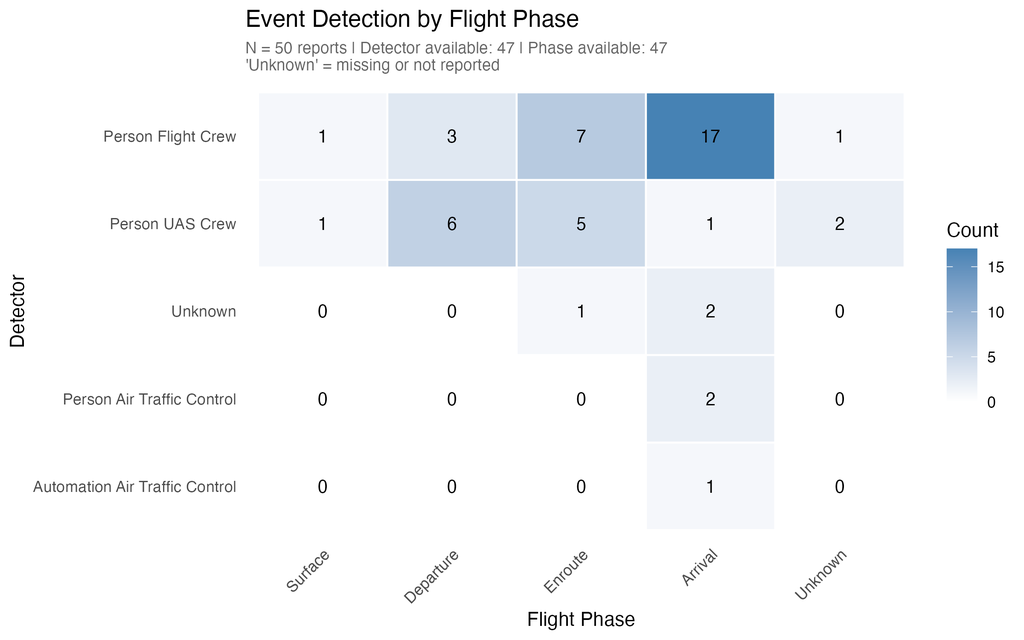

Figure 1. Event detection by flight phase

**Figure 2. Severity marker prevalence with Wilson 95% intervals**

*Caption*: How frequently do NMAC, evasive action, and ATC assistance markers appear in reports?

*Denominator note*: N = 50 reports. Wilson 95% confidence intervals shown.

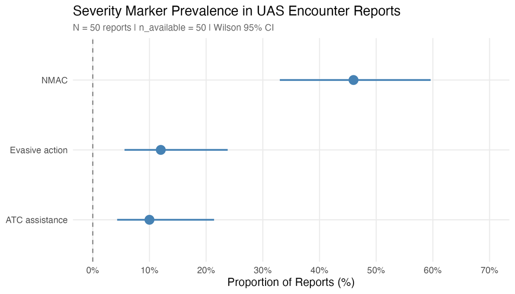

Figure 2. Severity marker prevalence with Wilson 95% intervals

**Figure 3. Dominant tags in UAS encounter reports**

*Caption*: What anomaly types and contributing factors are most frequently tagged?

*Denominator note*: N = 50 reports. Counts are report-level (each tag counted once per report regardless of repetition).

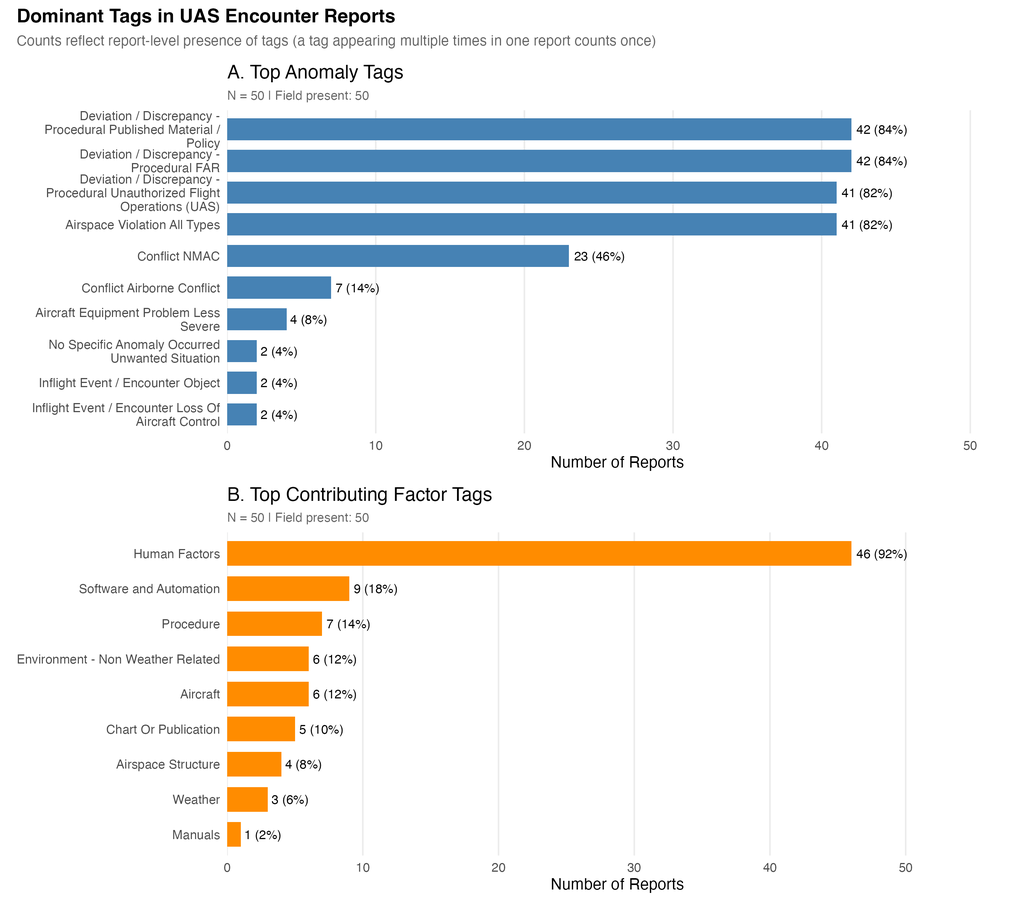

Figure 3. Dominant tags in UAS encounter reports

**Figure 4. NMAC prevalence by flight phase with Wilson 95% intervals**

*Caption*: How does NMAC prevalence vary by flight phase?

*Denominator note*: N = 50 reports. Groups with n >= 5 included in plot. Wilson 95% confidence intervals shown.

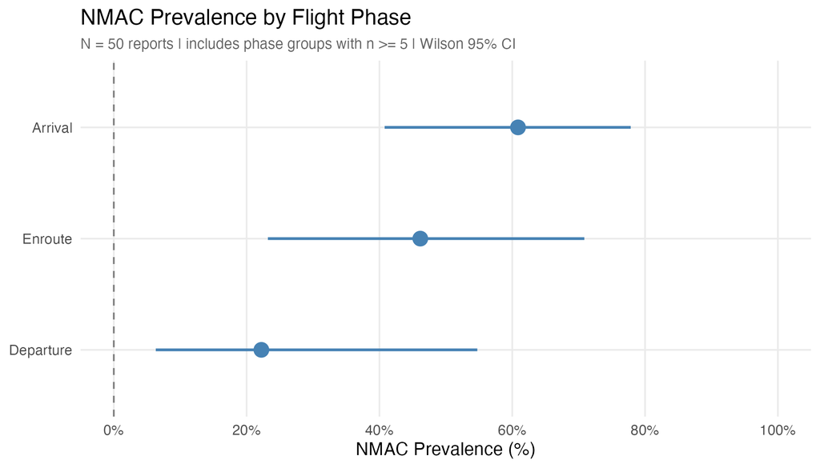

Figure 4. NMAC prevalence by flight phase with Wilson 95% intervals

**Figure 5. NMAC prevalence by detector with Wilson 95% intervals**

*Caption*: How does NMAC prevalence vary by detection source?

*Denominator note*: N = 50 reports. Groups with n >= 5 included in plot. Wilson 95% confidence intervals shown.

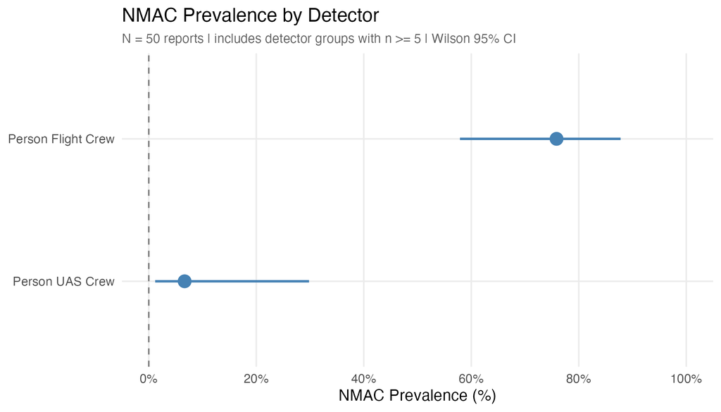

Figure 5. NMAC prevalence by detector with Wilson 95% intervals

**Figure 6. NMAC prevalence by time of day with Wilson 95% intervals**

*Caption*: How does NMAC prevalence vary by time of day?

*Denominator note*: N = 50 reports. Groups with n >= 5 included in plot. Wilson 95% confidence intervals shown.

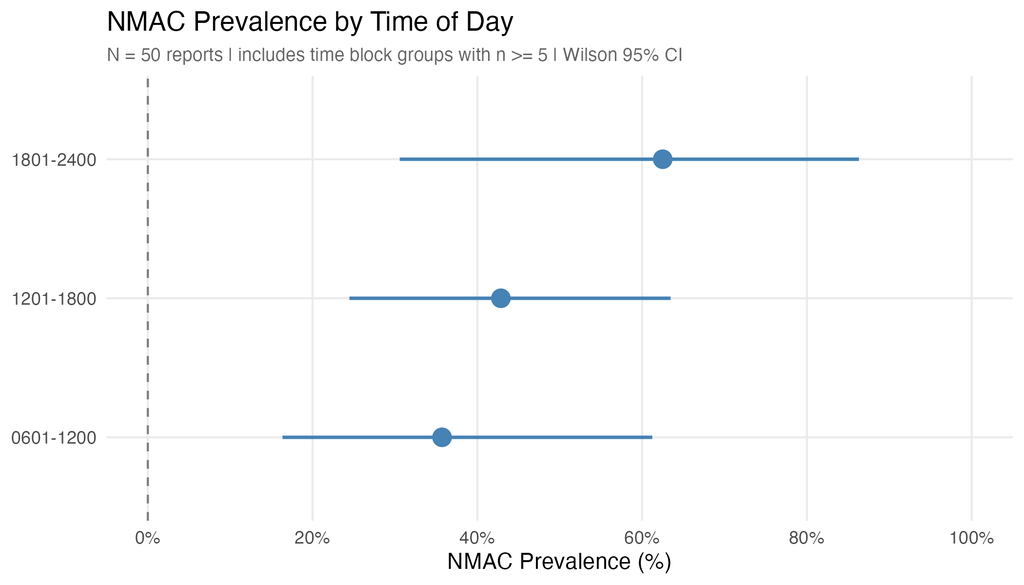

Figure 6. NMAC prevalence by time of day with Wilson 95% intervals

## Reproducibility

This document was generated from CSV and PNG outputs in `output/`.

**Assembly timestamp**: 2025-12-27 18:01:43

**Source scripts**:

- `scripts/eda/01_audit.R` through `10_build_inventory_captions.R`
- `scripts/eda/11_assemble_descriptives_qmd.R`

All numeric values in tables are programmatically generated from the underlying data to ensure consistency and prevent transcription errors.